# Time Series Forecasting

Now, we will try to build forecast model

```r
#create ts object
elec_ts = ts(data1[1:4891,2:4], start=c(1,6), end = c(51,96),frequency = 96)
```

Split our time series data set

```r
elec_ts_train= window(elec_ts, start=c(1,6), end=c(41,72))
elec_ts_test= window(elec_ts, start=c(41,73), end=c(51,96))
```

**AUTO ARIMA** We will use a dynamic regression model for forecasting electricity consumption, using temperature and cluster as external covariates. The order of the ARIMA model for the residual part is automatically selected

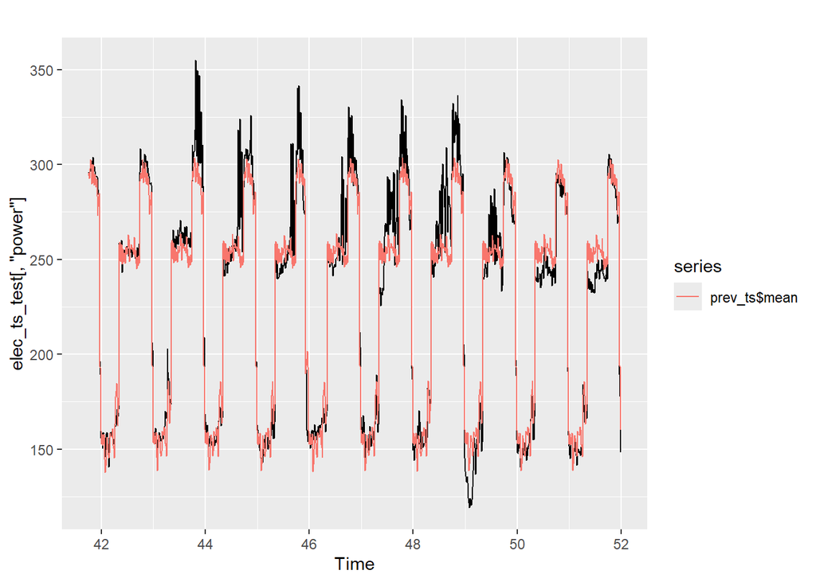

```r
fit_ts=auto.arima(elec_ts_train[,"power"],xreg=elec_ts_train[,2:3])
prev_ts=forecast(fit_ts,h=984,xreg=elec_ts_test[,2:3])
autoplot(elec_ts_test[,"power"])+autolayer(prev_ts$mean)
```

let’s evaluate:

```r
Autarima_ts_score = rmse(prev_ts$mean,elec_ts_test[,"power"])
Autarima_ts_score
```

```
## [1] 14.31118
```

we get better score than all the previous models.

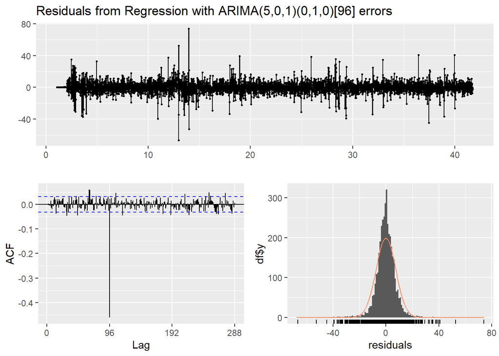

```
##
##  Ljung-Box test
##
## data:  Residuals from Regression with ARIMA(5,0,1)(0,1,0)[96] errors
## Q* = 1119.6, df = 186, p-value < 2.2e-16
##
## Model df: 6.   Total lags used: 192
```

```r
checkresiduals(fit_ts)
```

Most of the residuals’ autocorrelations are within the bounds, suggesting that the ARIMA model has captured the majority of the temporal structure. However, there is one significant spike at lag 96 which includes seasonal components explicitly. We will add one order MA in the seasonal pattern:

let’s improve it:

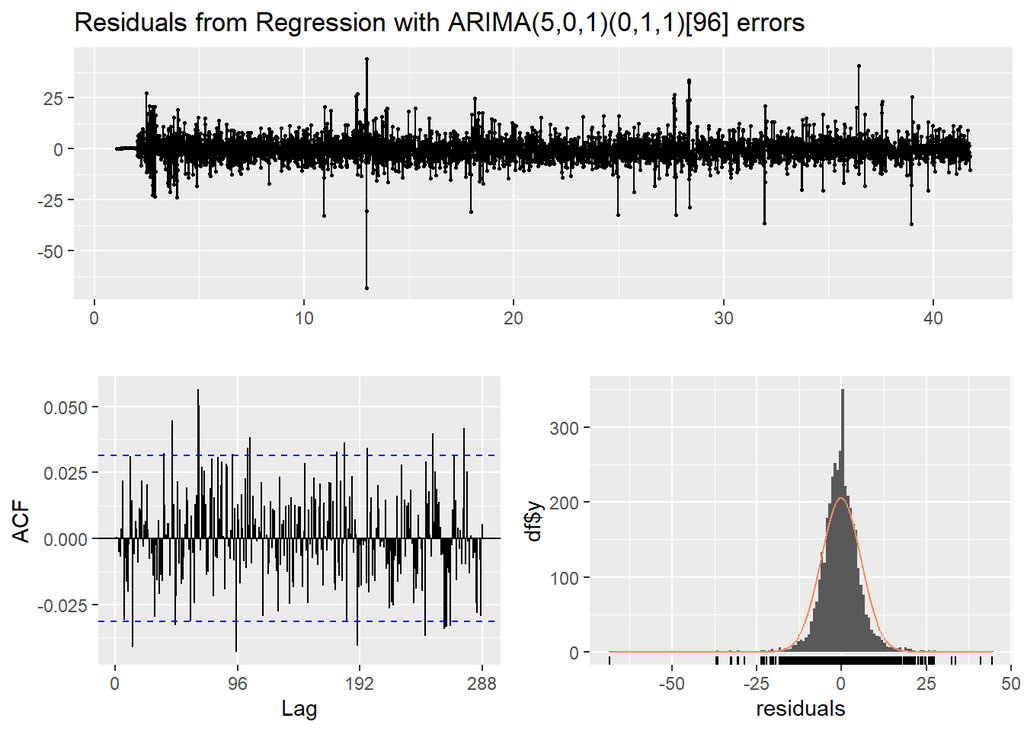

```
##
##  Ljung-Box test
##
## data:  Residuals from Regression with ARIMA(5,0,1)(0,1,1)[96] errors
## Q* = 241.06, df = 185, p-value = 0.003496
##
## Model df: 7.   Total lags used: 192
```

```r
fit2_ts=Arima(elec_ts_train[,"power"],xreg=elec_ts_train[,2:3],order=c(5,0,1),seasonal = c(0,1,1))
checkresiduals(fit2_ts)
```

let ’ evaluate it:

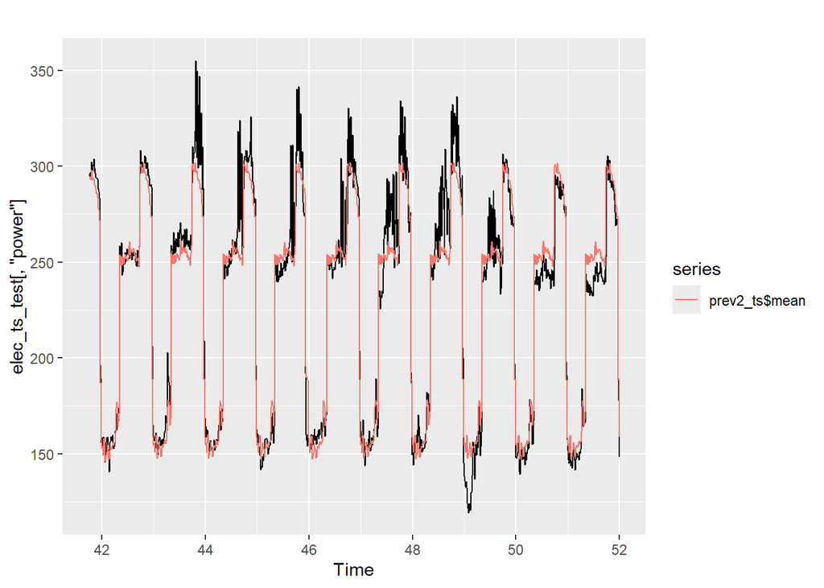

```r
prev2_ts=forecast(fit2_ts,h=984,xreg=elec_ts_test[,2:3])
autoplot(elec_ts_test[,"power"])+autolayer(prev2_ts$mean)
```

```r
Sarima_ts_score = rmse(prev2_ts$mean,elec_ts_test[,"power"])
Sarima_ts_score
```

```
## [1] 13.68597
```

The result are better than those obtained with the auto.arima function. Finally, we can compare with a NNAR model with covariates, but it does not improve the forecast.

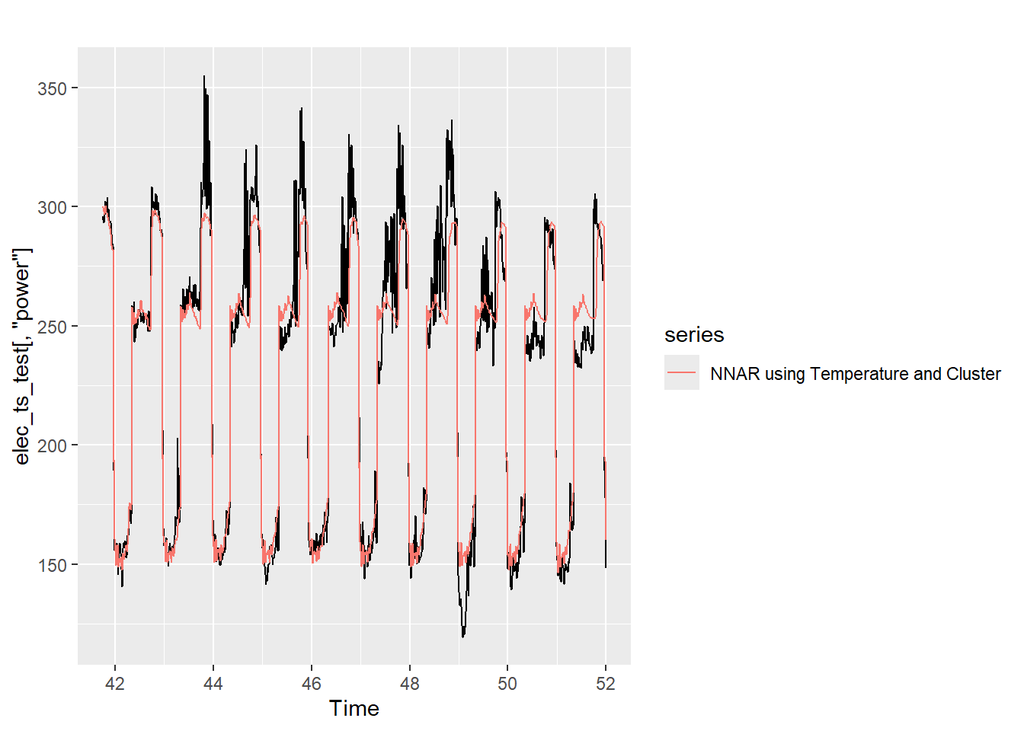

```r
fit_NN=nnetar(elec_ts_train[,"power"],xreg=elec_ts_train[,2:3])
prev_nnetar=forecast(fit_NN,h=984,xreg=elec_ts_test[,2:3])
autoplot(elec_ts_test[,"power"])+autolayer(prev_nnetar$mean,series="NNAR using Temperature and Cluster")
```

```r
summary(fit_NN)
```

```
##           Length Class        Mode
## x         3907   ts           numeric
## m            1   -none-       numeric
## p            1   -none-       numeric
## P            1   -none-       numeric
## scalex       2   -none-       list
## scalexreg    2   -none-       list
## size         1   -none-       numeric
## xreg      7814   mts          numeric
## subset    3907   -none-       numeric
## model       20   nnetarmodels list
## nnetargs     0   -none-       list
## fitted    3907   ts           numeric
## residuals 3907   ts           numeric
## lags        21   -none-       numeric
## series       1   -none-       character
## method       1   -none-       character
## call         3   -none-       call
```

```r
NNETAR_score= rmse(prev_nnetar$mean,elec_ts_test[,"power"])
NNETAR_score
```

```
## [1] 16.72188
```

#Third conclusion

let’s resume all score we get and choose the best one.

```r
cat('Forecasting results with temperature + Cluster : ' , '\n')
```

```
## Forecasting results with temperature + Cluster :
```

```r
cat('RMSE with Auto Arima is:', Autarima_ts_score,'\n')
```

```
## RMSE with Auto Arima is: 14.31118
```

```r
cat('RMSE with SARIMA model is:', Sarima_ts_score ,'\n')
```

```
## RMSE with SARIMA model is: 13.68597
```

```r
cat('RMSE with Neural Network model is:', NNETAR_score ,'\n')
```

```
## RMSE with Neural Network model is: 16.72188
```

create new ts for forecast

```r
datatoforcast= data.frame(
  Timestamp = seq(from = as.POSIXct("2010-02-21 00:00"),  by = "15 min", length.out=96),
  power = data$`Power (kW)`[4892:4987], Temp =data$`Temp (C°)`[4892:4987]
)
head(datatoforcast)
```

|  | Timestamp | power | Temp |
| --- | --- | --- | --- |
| 1 | 2010-02-21 00:00:00 | NA | 11.66667 |
| 2 | 2010-02-21 00:15:00 | NA | 11.66667 |
| 3 | 2010-02-21 00:30:00 | NA | 11.66667 |
| 4 | 2010-02-21 00:45:00 | NA | 11.66667 |
| 5 | 2010-02-21 01:00:00 | NA | 11.66667 |
| 6 | 2010-02-21 01:15:00 | NA | 10.55556 |

#*CONCLUSION*

```r
cat('Forecasting results : ' , '\n')
```

```
## Forecasting results :
```

```r
cat('RMSE with SARIMA model is:', sarima_model ,'\n')
```

```
## RMSE with SARIMA model is: 15.7896
```

```r
cat('RMSE with Neural Network model is:', NNETAR_score ,'\n')
```

```
## RMSE with Neural Network model is: 16.72188
```

```r
cat('RMSE with Random Forest is:', Random_Forest ,'\n')
```

```
## RMSE with Random Forest is: 15.95456
```

```r
cat('RMSE with XGB BOOST model is:', XG_boost ,'\n')
```

```
## RMSE with XGB BOOST model is: 16.87228
```